# Construire un graphe interactif avec R

Sergio Ewane Ebouele

2018-12-25 03:44:19

# LES PACKAGES R UTILISÉS DANS LE TUTORIEL

```r
library(dplyr)     # POUR MANIPULER LES JEUX DE DONNÉES
library(vegan)     # POUR FAIRE LES NULL MODELS
library(parallel)  # POUR LES CALCULS EN PARALÈLES
library(igraph)    # POUR CONSTRUIRE LES RESEAUX NON INTERACTIFS
library(rgl)       # POUR LES REPRÉSENTATIONS EN 3D
library(networkD3) # POUR CONSTRUIRE LES RESEAUX INTERACTIFS
```

# INTRODUCTION

La représentation graphique des données reste un moyen important pour l’exploration de l’information contenue dans les jeux de données. Ce tutoriel montre comment procéder pour construire un graphe interactif avec `R`.

# DÉFINITION DE GRAPHES

D’après l’encyclopédie en ligne Wikipédia, La théorie des graphes est la discipline mathématique et informatique qui étudie les graphes.  
Un graphe est un modèle abstrait de dessins de réseaux reliant des objets. Ce modèle est constitué par la donnée de points, appelés `nœuds` ou sommets (en référence aux polyèdres), et de `liens` entre ces points. ces liens sont souvent symétriques (les graphes sont alors dits non orientés) et sont appelés des arêtes. L’image ci-dessous illutre la définition d’un graphe non orienté.

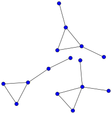

Ce tutoriel ne revient pas sur la théorie des graphes. Il illustre simplement la construction des graphes non orientés et interactif avec `R`.

# EXEMPLE PRATIQUE : REPRÉSENTATION DES LIENS ENTRE LES ÉTUDIANTS

Les données de ce papier sont fictives. Il s’agit d’un ensemble de `23` étudiants d’une salle de classe qui participent aux activités parascolaires chaque fin de semaines. Sur la base de leur participation aux activités, le papier représente graphiquement les liens significatifs (et leur sens) qui existent entre les étudiants.

## La matrice de présence-absence (Mpa) aux activités parascolaires

Les lignes de la Mpa représentent les étudiants et les colonnes représentent les activités. Une cellule `(i,j)` est évaluée à `1` si l’étudiant `i` participe à l’activité `j`. Elle est évaluée à `0` si l’étudiant `i` ne participe pas à l’activité `j`.  
Pour cet exemple, les étudiants fréquentent plus les `restaurants` pendant leur fin de semaine et participent plus aux parties de `soccer` ou de `cinéma`. Ils se rendent très peu à la `ferme` et à la `bibliothèque` pendant le week-end.  
`Maxi` et la `LaHossou` sont les deux étudiants qui participent le plus aux activités en fin de semaine. Le premier est absent des activités réligieuses et le second ne se rend pas dans les clubs de dance. Par contre, `LeDidier` et `LeCherif` sont des étudiants très casaniers. Le premier se rend uniquement dans des club de dance et le second participe aux activités religieuses et se rend au restaurant.  
Face à cette description, est ce vrai de croire que `Maxi` et `LaHossou` ont un lien de similarité particulier ? ou encore, existe t-il un lien de dissimilarité entre `Maxi` et `LeCherif` ou entre `LaHossou` et `LeDidier`?  
La suite du tutoriel essaye de répondre à toutes ces interrogations.

| Etudiants | group | Cine | Soccer | Biblio | Club | Religion | Ferme | Resto |
| --- | --- | --- | --- | --- | --- | --- | --- | --- |
| Bertholo | grp4 | 1 | 0 | 1 | 0 | 1 | 0 | 1 |
| Vanou | grp4 | 1 | 0 | 1 | 0 | 1 | 0 | 1 |
| Carmelito | grp4 | 1 | 1 | 1 | 1 | 0 | 0 | 0 |
| LeMaham | grp2 | 0 | 1 | 0 | 0 | 1 | 0 | 1 |
| Serge | grp2 | 1 | 1 | 0 | 0 | 0 | 1 | 1 |
| Reine | grp4 | 0 | 0 | 1 | 0 | 1 | 1 | 1 |
| Nelly | grp4 | 0 | 0 | 1 | 0 | 1 | 1 | 0 |
| Astro | grp4 | 1 | 0 | 1 | 1 | 0 | 0 | 1 |
| Maxi | grp4 | 1 | 1 | 1 | 0 | 0 | 1 | 1 |
| Sorelite | grp1 | 0 | 1 | 0 | 1 | 0 | 1 | 0 |

[output cut: 13 more lines]

## La structure de regroupement des étudiants

Les figures ci-dessous montrent qu’il existe une structure de cooccurrence negative entre les étudiants. La présentation du concept des `null models` est faite dans un autre tutoriel.  
L’idée des `null models` est de comparer le hasard à ce qui est observée. Si le jeu de données observé ressemble aux jeux de données obtenus dans une situation de hasard alors on dira qu’il n’existe aucune structure de regroupement dans la communauté. Sinon, il existe une structure particulière qu’il faut analyser. Cette notion est très utilisée en biologie, plus particulièrement en écologie.  
Pour faire le parallèle avec notre exemple, les étudiants sont similaires aux espèces et les activités sont similaires aux sites.

|  | Indice_temperature | Indice_N0 | Indice_NODF | Indice_Cscore |
| --- | --- | --- | --- | --- |
| p.value | 0.2 | 0.884 | 0.872 | 0.062 |

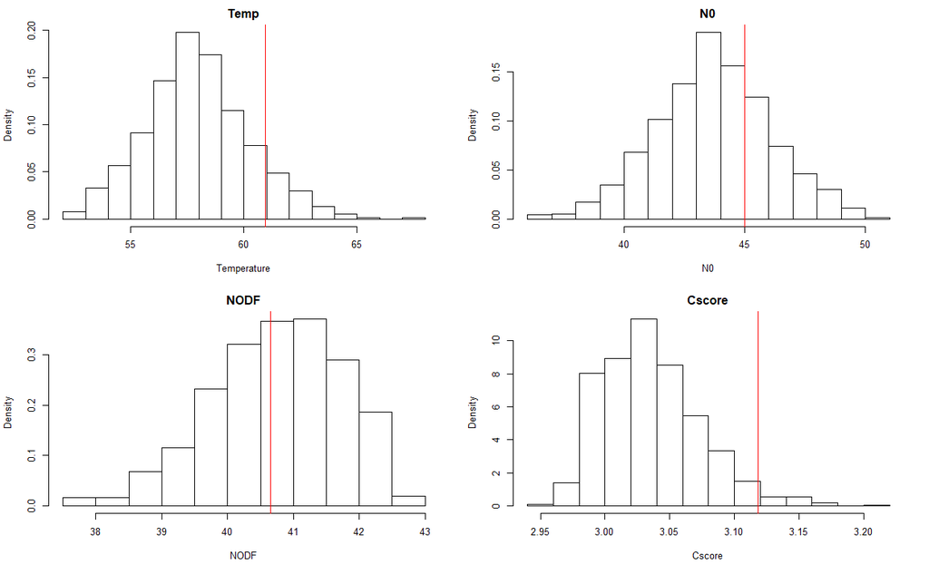

## La matrice de liens significatifs entre les étudiants

Pour analyser la structure de cooccurrence détectée ci-dessus, le tutoriel mesure le lien entre les étudiants. On peut utiliser plusieurs métrique pour quantifier la distance entre deux étudiants. Dans ce contexte particulier, l’indice de simmilarité de `Sorensen` est la plus courante. Cette diatance mesure la similarité ou la dissimilarité entre deux entités de la `Mpa`. Un lien est significatif lorsqu’il est très différent des liens déterminé par le hasard. Le tableau ci dessous présente la matrice de lien entre les étudiants, leur niveau de significativité et leur type (similarité ou dissimilarité).  
La variable `Cooc` mesure le niveau de cooccurrence entre les espèces. En fait, il représente le nombre de fois où deux étudiants se sont retrouvé dans la même activité. Si sa valeur est plus faible que la moyenne alors les etudiants sont dissimilaires, sinon ils sont similaires. Pour représenter un reseau important, le seuil de significativité d’un lien a été fixé à `alpha=21%`. Pour des études réelles, il est conseillé de choisir l’un des seuils suivants : `10%` , `5%` ou `1%`.

|  | from | to | Sor | cooc | p.val.cooc | meanSimCooc | sens.cooc |
| --- | --- | --- | --- | --- | --- | --- | --- |
| 1 | Bertholo | Vanou | 1.00 | 4 | 0.072 | 2.321 | Similarite |
| 9 | Bertholo | Sorelite | 0.00 | 0 | 0.054 | 1.731 | Dissimilarite |
| 30 | Vanou | Sorelite | 0.00 | 0 | 0.040 | 1.754 | Dissimilarite |
| 79 | LeMaham | Afann | 0.00 | 0 | 0.190 | 1.361 | Dissimilarite |
| 99 | Serge | LeCyp | 0.25 | 1 | 0.168 | 2.319 | Dissimilarite |

## Représentations graphiques

### Représentation du graphe non interactif

Cette représentation ne permet pas d’interagir avec le graphique. Il est possible de pondérer les liens du réseau par un poids mais il reste difficile d’y ajouter des couleurs relativement à un facteur. Pour plus de précision sur ce type de représentation, le lecteur peut consulter la page suivante : igraph

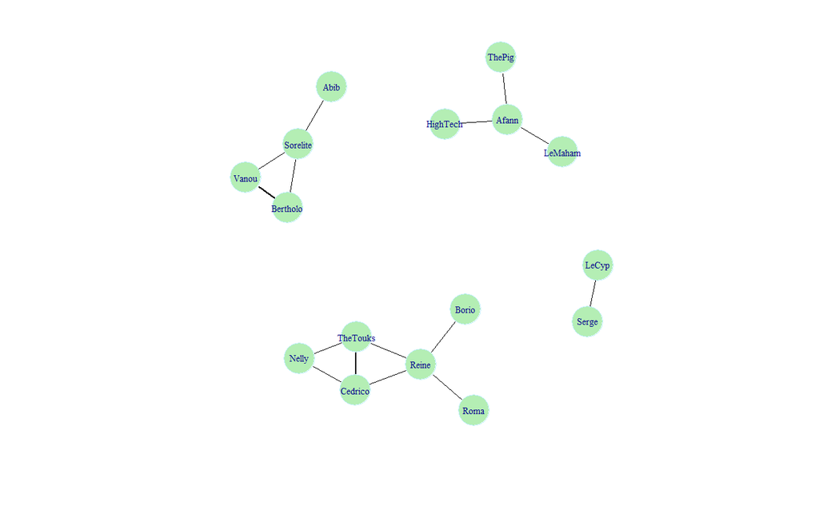

```r
###########################################
# CODE R POUR CONSTRUIRE LES RESEAUX NONS #
# INTERACTIFS                             #
###########################################
# Définir les couleurs du graphe
color1<-"darkseagreen2" ; color2<-"lightblue1" ; color3<-"black"
# Jeu de données pour représenter le graphe
bdgraph<-Test.cooc[,c("from","to","Sor")]
g=graph.data.frame(bdgraph[,-3], directed=FALSE)
graph_layout=layout.fruchterman.reingold(g)
# Représentation du graphe
plot.igraph(g,
     layout=graph_layout,
     edge.width=(exp(bdgraph$Sor)),
     vertex.label.cex=0.9,
     vertex.color=color1,
     vertex.frame.color=color2,
     vertex.size=18,
     edge.color=color3
)
```

### Représentation du graphe interactif

Contrairement au graphe ci-dessus, la représentation des réseaux à l’aide de la fonction [forceNetwork()](https://www.rdocumentation.org/packages/networkD3/versions/0.4) du package networkD3 est interactive. Le résultats de cette fonction permet de mettre en surbrillance les liens d’un sommet particulier.

Pour arriver à un tel résultat, la fonction prend en entré plusieurs arguments. Les plus importants sont :

- Le data frame `MyNodes`: décrit les noeuds du réseau. On y retrouve les noms des noeuds, leur groupe d’appartenance et leur taille. Les deux dernière variables sont facultatives. Seule la première variable est obligatoire et doit être de type `factor`.
- Le data frame `MyLinks`: décrit les liens du réseau. Il a deux variables obligatoires et plusieurs autres facultatives. Chaque ligne de ce jeu de données représente un lien du réseau. Un lien est caractérisé par l’origine (`from`) et la destination (`to`), le poids du lien (`Cooc`, caractéristique facultative), le groupe d’appartenance du lien (`typeLink`, une variable de type factor) etc. NB: les variables `from` et `to` doivent être les numéros des facteurs définis dans le data frame `MyNodes`. Pour représenter le réseau, la fonction utilise un code JavaScript. Pour cette raison, les variables d’origine-destination du réseau sont indexés à `0` (les numéros des facteurs doivent commencer à `0`).

Ci-dessous, vous verrez le code et l’en-tête des data frame utilisés pour construire le reseau des étudiants basé sur leur fréquentation commune de certaines activités extra scolaire.

```r
######################################################
# CODE R POUR CONSTRUIRE UN RESEAU INTERACTIF AVEC R #
######################################################
# Les noeuds du graphe
vertx<-as.factor(vertex.attributes(g)$name)
nnod<-length(vertx)
netw3d.from<-as.character(Test.cooc$from)
netw3d.to<-as.character(Test.cooc$to)
# Création du jeu de données de description des noeud
# Nom des noeuds
MyNodes<-data.frame( species=levels(vertx) )  ;  group<-c()
# Groupe des noeuds
for (i in 1:nnod) {
  nom.e<-as.character(etudiants$Etudiants)
  grp.e<-etudiants[nom.e==as.character(MyNodes[i,]),2]
  grp<-as.character(grp.e)
  group<-c(group,grp)
}
# resultat
MyNodes<-data.frame( student=levels(vertx) ,
                     group=factor(group) ,
                     size=rep(5,nnod))
# Jeu de données qui spécifie les liens entre les étudiants
# ( On fait -1 pour indexer à 0)
# (+1 pour eviter des liens nuls)
MyLinks<-data.frame(from=as.double(factor(netw3d.from,levels(vertx)))-1,
                    to=as.double(factor(netw3d.to,levels(vertx)))-1,
                    Cooc=Test.cooc$cooc+1,
                    typeLink=as.factor(Test.cooc$sens.cooc ))
# Vecteur de couleur des liens entre les étudiants
Colinks<-ifelse(MyLinks$typeLink=="Similarite","black","red")
MyLinks$Linkcolor<-Colinks
# Représentation du graphe
forceNetwork(Links = MyLinks, Nodes = MyNodes, Source = "from",
             Target = "to", Value = "Cooc", NodeID = "student",
             Group = "group", opacity = 0.9, Nodesize = "size",
             linkDistance = 90, fontSize = 20, linkColour = Colinks,
             legend = TRUE)
```

[interactive chart not shown]

`Les data frame MyNodes et MyLinks`

|  | student | group | size |
| --- | --- | --- | --- |
| 1 | Abib | grp1 | 5 |
| 2 | Afann | grp4 | 5 |
| 3 | Bertholo | grp4 | 5 |

|  | from | to | Cooc | typeLink | Linkcolor |
| --- | --- | --- | --- | --- | --- |
| 1 | 2 | 15 | 5 | Similarite | black |
| 2 | 2 | 12 | 1 | Dissimilarite | red |
| 3 | 15 | 12 | 1 | Dissimilarite | red |

# DISCUSSION

Le réseau montre que les liens entre `LeCherif` et `Maxi` et entre `LeDidier` et `LaHossou` ne sont pas significatif. `Maxi` et `LaHossou` n’existent pas dans ce reseau. En effet, leur présence ou leur absence ne permet pas de prédire avec un niveau éleve de confiance le comportement d’un autre étudiant (ils participent à presque toutes les activités, donc ils n’apportent aucune information particulière). Par contre, on peut remarquer que `Vanou` et `Bertholo` participent de manière significative aux mêmes activités et tous deux ont des comportements opposés à ceux de `Sorelite`. Pour ces trois derniers étudiants, on peut prédire avec un niveau de confiance élevé le comportement de l’un à partir de celui de l’autre.